# Mitral Valve Replacement Data Simulation

## Simulated Data Exploration

#### Summary of Bioprosthetics group

```r
summary(death_bioprosthetics)
```

```
##       age            sex                      race     emergent_admission
##  Min.   :47.43   female:395   Hispanic          : 57   Min.   :0.0000
##  1st Qu.:57.29   male  :269   Non_Hispanic_Black: 86   1st Qu.:0.0000
##  Median :60.48                Non_Hispanic_White:370   Median :1.0000
##  Mean   :60.56                Other             :151   Mean   :0.5361
##  3rd Qu.:64.13                                         3rd Qu.:1.0000
##  Max.   :73.15                                         Max.   :1.0000
##
##  concomitant_tricuspid_valve_repair  coagulation       hypertension
##  Min.   :0.00000                    Min.   :0.00000   Min.   :0.0000
##  1st Qu.:0.00000                    1st Qu.:0.00000   1st Qu.:0.0000
##  Median :0.00000                    Median :0.00000   Median :1.0000
##  Mean   :0.06175                    Mean   :0.07078   Mean   :0.5738
##  3rd Qu.:0.00000                    3rd Qu.:0.00000   3rd Qu.:1.0000
##  Max.   :1.00000                    Max.   :1.00000   Max.   :1.0000
##
##  diabetes_mellitus     sepsis
##  Min.   :0.000     Min.   :0.00000
##  1st Qu.:0.000     1st Qu.:0.00000
##  Median :0.000     Median :0.00000
##  Mean   :0.256     Mean   :0.04367
##  3rd Qu.:1.000     3rd Qu.:0.00000
##  Max.   :1.000     Max.   :1.00000
##
##                     coronary_artery_disease congestive_heart_failure
##  None                           :388        Min.   :0.0000
##  Prior_CABG_Surgery             : 44        1st Qu.:0.0000
##  Prior_PCI                      : 23        Median :1.0000
##  Without_Prior_Revascularization:209        Mean   :0.5858
##                                             3rd Qu.:1.0000
##                                             Max.   :1.0000
##
##  atrial_fibrillation peripheral_vascular_disease cerebro_vascular_disease
##  Min.   :0.0000      Min.   :0.00000             Min.   :0.00000
##  1st Qu.:0.0000      1st Qu.:0.00000             1st Qu.:0.00000
##  Median :0.0000      Median :0.00000             Median :0.00000
##  Mean   :0.4066      Mean   :0.04217             Mean   :0.09488
##  3rd Qu.:1.0000      3rd Qu.:0.00000             3rd Qu.:0.00000
##  Max.   :1.0000      Max.   :1.00000             Max.   :1.00000
##
```

[output cut: 9 more lines]

```
##  Min.   :0.00000   Min.   :0.00000   2007   :111   bio:664
##  1st Qu.:0.00000   1st Qu.:0.00000   2006   :102
##  Median :0.00000   Median :0.00000   2005   : 89
##  Mean   :0.05723   Mean   :0.03464   2004   : 85
##  3rd Qu.:0.00000   3rd Qu.:0.00000   2003   : 63
##  Max.   :1.00000   Max.   :1.00000   2001   : 56
##                                      (Other):158
##      death
##  Min.   :0.0000
##  1st Qu.:0.0000
##  Median :0.0000
##  Mean   :0.3961
##  3rd Qu.:1.0000
##  Max.   :1.0000
##
```

#### Summary of Mechanical prosthetics group

```r
summary(death_mechprosthetics)
```

```
##       age            sex                      race     emergent_admission
##  Min.   :47.44   female:395   Hispanic          : 52   Min.   :0.0000
##  1st Qu.:57.29   male  :269   Non_Hispanic_Black: 58   1st Qu.:0.0000
##  Median :60.48                Non_Hispanic_White:357   Median :0.0000
##  Mean   :60.56                Other             :197   Mean   :0.4021
##  3rd Qu.:64.12                                         3rd Qu.:1.0000
##  Max.   :73.14                                         Max.   :1.0000
##
##  concomitant_tricuspid_valve_repair  coagulation       hypertension
##  Min.   :0.00000                    Min.   :0.00000   Min.   :0.0000
##  1st Qu.:0.00000                    1st Qu.:0.00000   1st Qu.:0.0000
##  Median :0.00000                    Median :0.00000   Median :1.0000
##  Mean   :0.03163                    Mean   :0.06325   Mean   :0.5271
##  3rd Qu.:0.00000                    3rd Qu.:0.00000   3rd Qu.:1.0000
##  Max.   :1.00000                    Max.   :1.00000   Max.   :1.0000
##
##  diabetes_mellitus     sepsis
##  Min.   :0.0000    Min.   :0.00000
##  1st Qu.:0.0000    1st Qu.:0.00000
##  Median :0.0000    Median :0.00000
##  Mean   :0.1596    Mean   :0.01657
##  3rd Qu.:0.0000    3rd Qu.:0.00000
##  Max.   :1.0000    Max.   :1.00000
##
##                     coronary_artery_disease congestive_heart_failure
##  None                           :467        Min.   :0.0000
##  Prior_CABG_Surgery             : 34        1st Qu.:0.0000
##  Prior_PCI                      : 13        Median :1.0000
##  Without_Prior_Revascularization:150        Mean   :0.5181
##                                             3rd Qu.:1.0000
##                                             Max.   :1.0000
##
##  atrial_fibrillation peripheral_vascular_disease cerebro_vascular_disease
##  Min.   :0.0000      Min.   :0.00000             Min.   :0.00000
##  1st Qu.:0.0000      1st Qu.:0.00000             1st Qu.:0.00000
##  Median :1.0000      Median :0.00000             Median :0.00000
##  Mean   :0.5166      Mean   :0.03163             Mean   :0.07982
##  3rd Qu.:1.0000      3rd Qu.:0.00000             3rd Qu.:0.00000
##  Max.   :1.0000      Max.   :1.00000             Max.   :1.00000
##
```

[output cut: 9 more lines]

```
##  Min.   :0.00000   Min.   :0.0000   1998   : 88   mechanical:664
##  1st Qu.:0.00000   1st Qu.:0.0000   1999   : 73
##  Median :0.00000   Median :0.0000   2001   : 70
##  Mean   :0.04066   Mean   :0.0256   2002   : 66
##  3rd Qu.:0.00000   3rd Qu.:0.0000   1997   : 63
##  Max.   :1.00000   Max.   :1.0000   2003   : 63
##                                     (Other):241
##      death
##  Min.   :0.0000
##  1st Qu.:0.0000
##  Median :0.0000
##  Mean   :0.2952
##  3rd Qu.:1.0000
##  Max.   :1.0000
##
```

#### Exploration by plotting

**Bioprosthetic Group**

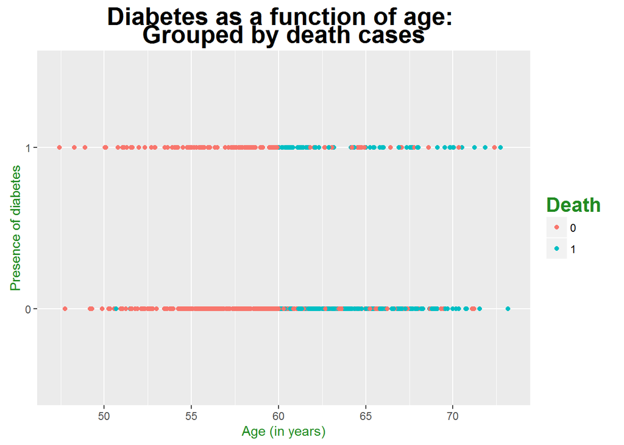

```r
ggplot(data = death_bioprosthetics,
            aes(x = age, y = as.factor(diabetes_mellitus), color = as.factor(death))) +
  geom_point() +
  labs(x="Age (in years)", y="Presence of diabetes", title="Diabetes as a function of age: \nGrouped by death cases") +
  theme(plot.title = element_text(size=20, face="bold", vjust=1, lineheight=0.6),
        legend.title = element_text(colour="forestgreen", size=16, face="bold"),
        axis.title.x = element_text(color="forestgreen", vjust=-0.35),
      axis.title.y = element_text(color="forestgreen" , vjust=0.35))+
  scale_color_discrete(name="Death")
```

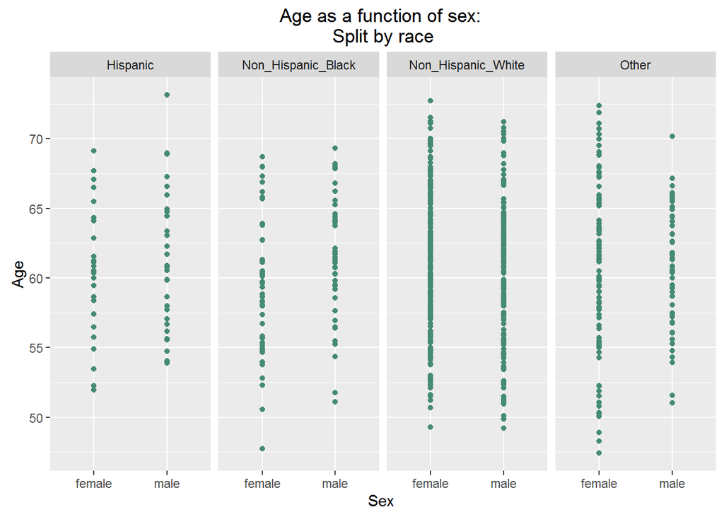

```r
ggplot(data = death_bioprosthetics,
       aes(x = sex, y = age))+
  geom_point(color="aquamarine4")+facet_wrap(~race, nrow=1)+
  labs(x="Sex ", y="Age", title="Age as a function of sex: \nSplit by race")
```

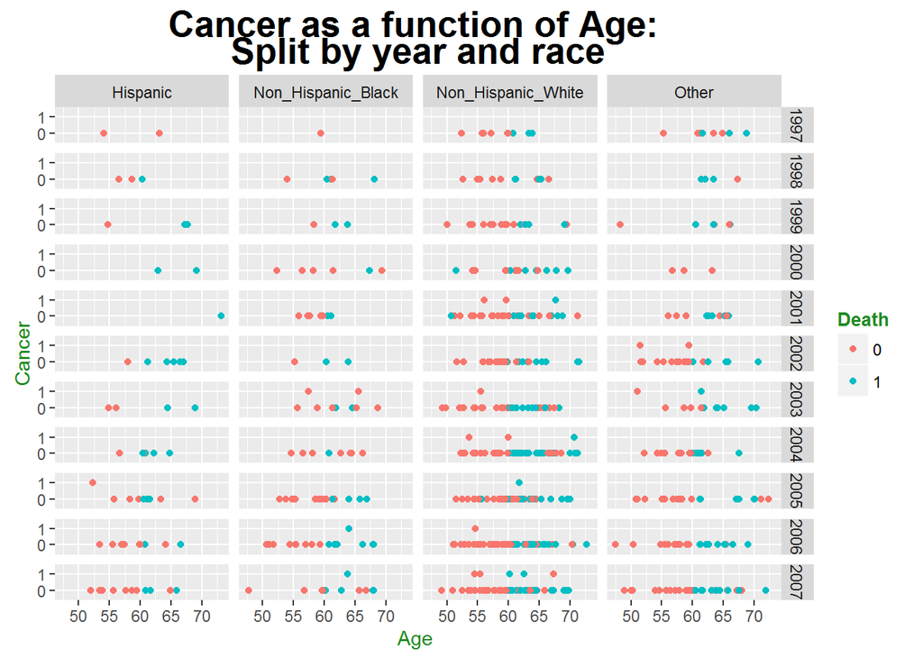

```r
ggplot(data = death_bioprosthetics, aes(age,as.factor(cancer), color = as.factor(death)))+
  geom_point()+
    facet_grid(year~race)+
  labs(x="Age ", y="Cancer", title="Cancer as a function of Age: \nSplit by year and race") + theme(plot.title = element_text(size=20, face="bold", vjust=1, lineheight=0.6),
        legend.title = element_text(colour="forestgreen", size=10, face="bold"),
        axis.title.x = element_text(color="forestgreen", vjust=-0.35),
      axis.title.y = element_text(color="forestgreen" , vjust=0.35))+
  scale_color_discrete(name="Death")
```

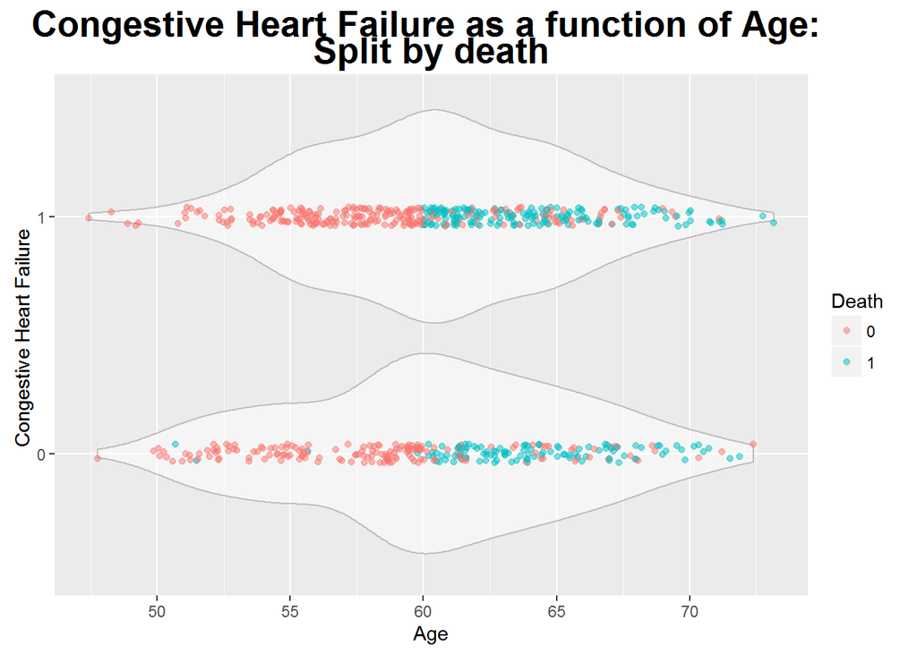

```r
ggplot(data = death_bioprosthetics, aes(as.factor(congestive_heart_failure), age)) +
  geom_violin(alpha=0.5, color="gray") +
  geom_jitter(alpha=0.5, aes(color = as.factor(death)), position = position_jitter(width = 0.1)) +
  coord_flip() +
  labs(x="Congestive Heart Failure ", y="Age", title="Congestive Heart Failure as a function of Age: \nSplit by death") +
  theme(plot.title = element_text(size=20, face="bold", vjust=1, lineheight=0.6)) +
  scale_color_discrete(name="Death")
```

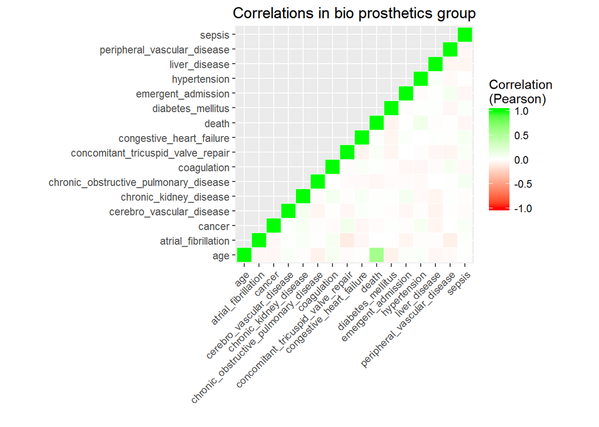

```r
thecor <- round(cor(death_bioprosthetics[,sort(c("age", "emergent_admission",
                                               "concomitant_tricuspid_valve_repair", "coagulation",
                                               "hypertension","diabetes_mellitus", "sepsis",
                                               "congestive_heart_failure", "atrial_fibrillation",
                                               "peripheral_vascular_disease",
                                               "cerebro_vascular_disease",
                                               "chronic_obstructive_pulmonary_disease",
                                               "chronic_kidney_disease", "liver_disease", "cancer",
                                               "death"))],
                  method="pearson",
                  use="pairwise.complete.obs"),
              2)
thecor[lower.tri(thecor)]<-NA
#thecor

thecor<-melt(thecor)
thecor$Var1<-as.character(thecor$Var1)
thecor$Var2<-as.character(thecor$Var2)
#Now we will use the "long" format using the melt function from the reshape2 package and I'll drop the records with NA values.
thecor<-na.omit(thecor)

ggplot(thecor, aes(Var2, Var1))+
 geom_tile(data=thecor, aes(fill=value), color="white")+
 scale_fill_gradient2(low="red", high="green", mid="white",
  midpoint=0, limit=c(-1,1),name="Correlation\n(Pearson)")+
 theme(axis.text.x = element_text(angle=45, vjust=1, hjust=1))+
 coord_equal() +
  labs(title="Correlations in bio prosthetics group", x = "", y = "")
```

Positive Correlations We can see that there are is a strong correlations in the data. Death and age are highly positively correlated. This is so because we coded it that way. Another important point to notice is that even though we did not generate a correlation of death with hypertention, our data suggests a positive correlation between the two.

**Mechanical prosthetic**

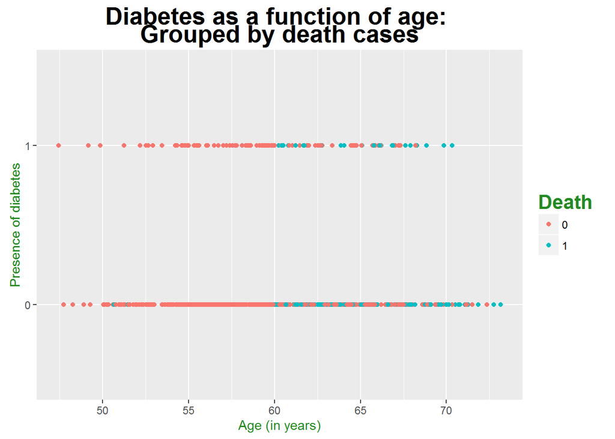

```r
ggplot(data = death_mechprosthetics,
            aes(x = age, y = as.factor(diabetes_mellitus), color = as.factor(death))) +
  geom_point() +
  labs(x="Age (in years)", y="Presence of diabetes", title="Diabetes as a function of age: \nGrouped by death cases") +
  theme(plot.title = element_text(size=20, face="bold", vjust=1, lineheight=0.6),
        legend.title = element_text(colour="forestgreen", size=16, face="bold"),
        axis.title.x = element_text(color="forestgreen", vjust=-0.35),
      axis.title.y = element_text(color="forestgreen" , vjust=0.35))+
  scale_color_discrete(name="Death")
```

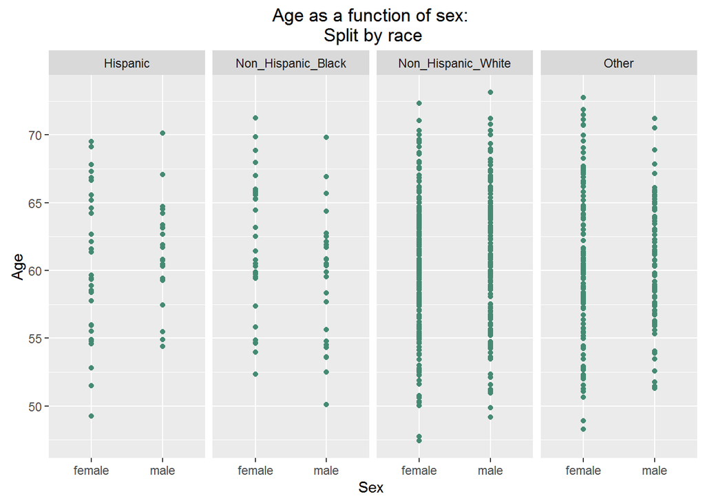

```r
ggplot(data = death_mechprosthetics,
       aes(x = sex, y = age))+
  geom_point(color="aquamarine4")+facet_wrap(~race, nrow=1)+
  labs(x="Sex ", y="Age", title="Age as a function of sex: \nSplit by race")
```

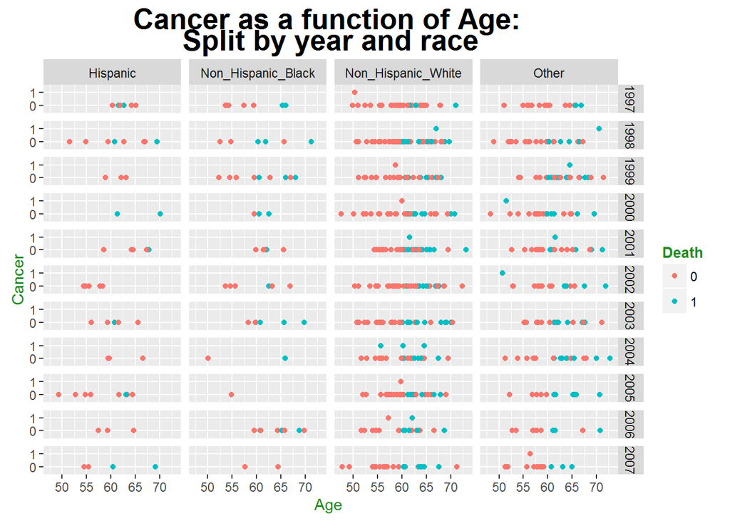

```r
ggplot(data = death_mechprosthetics, aes(age,as.factor(cancer), color = as.factor(death)))+
  geom_point()+
    facet_grid(year~race)+
  labs(x="Age ", y="Cancer", title="Cancer as a function of Age: \nSplit by year and race") + theme(plot.title = element_text(size=20, face="bold", vjust=1, lineheight=0.6),
        legend.title = element_text(colour="forestgreen", size=10, face="bold"),
        axis.title.x = element_text(color="forestgreen", vjust=-0.35),
      axis.title.y = element_text(color="forestgreen" , vjust=0.35))+
  scale_color_discrete(name="Death")
```

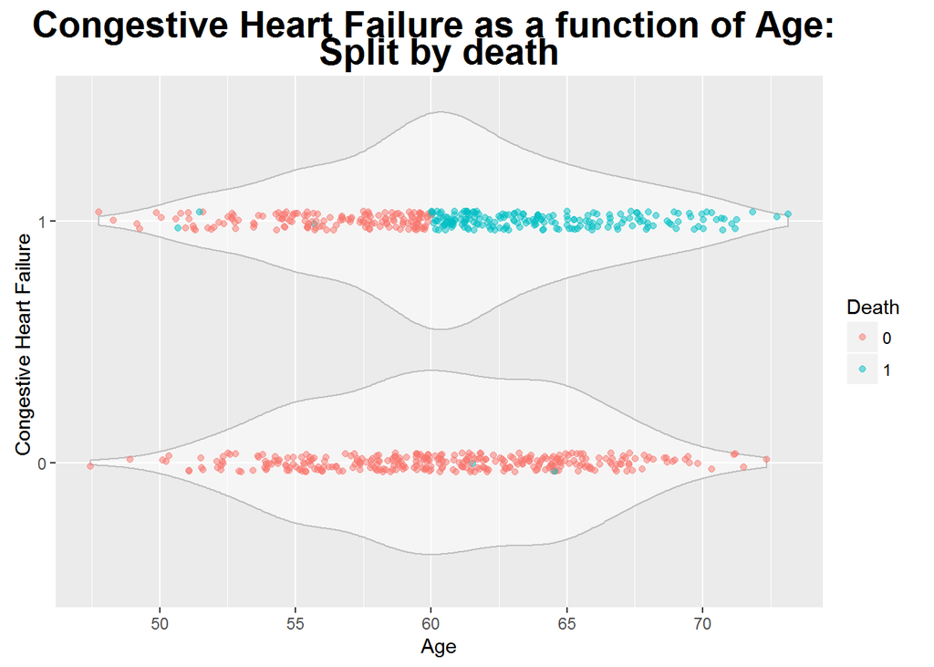

```r
ggplot(data = death_mechprosthetics, aes(as.factor(congestive_heart_failure), age)) +
  geom_violin(alpha=0.5, color="gray") +
  geom_jitter(alpha=0.5, aes(color = as.factor(death)), position = position_jitter(width = 0.1)) +
  coord_flip() +
  labs(x="Congestive Heart Failure ", y="Age", title="Congestive Heart Failure as a function of Age: \nSplit by death") +
  theme(plot.title = element_text(size=20, face="bold", vjust=1, lineheight=0.6)) +
  scale_color_discrete(name="Death")
```

```r
thecor<-round(cor(death_mechprosthetics[,sort(c("age", "emergent_admission",
                                               "concomitant_tricuspid_valve_repair", "coagulation",
                                               "hypertension","diabetes_mellitus", "sepsis",
                                               "congestive_heart_failure", "atrial_fibrillation",
                                               "peripheral_vascular_disease",
                                               "cerebro_vascular_disease",
                                               "chronic_obstructive_pulmonary_disease",
                                               "chronic_kidney_disease", "liver_disease", "cancer",
                                               "death"))],
                  method="pearson",
                  use="pairwise.complete.obs"),
              2)
thecor[lower.tri(thecor)]<-NA
print(thecor)
```

```
##                                       age atrial_fibrillation cancer
## age                                     1               -0.01  -0.03
## atrial_fibrillation                    NA                1.00   0.04
## cancer                                 NA                  NA   1.00
## cerebro_vascular_disease               NA                  NA     NA
## chronic_kidney_disease                 NA                  NA     NA
## chronic_obstructive_pulmonary_disease  NA                  NA     NA
## coagulation                            NA                  NA     NA
## concomitant_tricuspid_valve_repair     NA                  NA     NA
## congestive_heart_failure               NA                  NA     NA
## death                                  NA                  NA     NA
## diabetes_mellitus                      NA                  NA     NA
## emergent_admission                     NA                  NA     NA
## hypertension                           NA                  NA     NA
## liver_disease                          NA                  NA     NA
## peripheral_vascular_disease            NA                  NA     NA
## sepsis                                 NA                  NA     NA
##                                       cerebro_vascular_disease
## age                                                       0.09
## atrial_fibrillation                                       0.00
## cancer                                                   -0.01
## cerebro_vascular_disease                                  1.00
## chronic_kidney_disease                                      NA
## chronic_obstructive_pulmonary_disease                       NA
## coagulation                                                 NA
## concomitant_tricuspid_valve_repair                          NA
## congestive_heart_failure                                    NA
## death                                                       NA
## diabetes_mellitus                                           NA
## emergent_admission                                          NA
## hypertension                                                NA
## liver_disease                                               NA
## peripheral_vascular_disease                                 NA
## sepsis                                                      NA
##                                       chronic_kidney_disease
## age                                                    -0.03
## atrial_fibrillation                                     0.01
## cancer                                                 -0.01
## cerebro_vascular_disease                                0.06
## chronic_kidney_disease                                  1.00
```

[output cut: 115 more lines]

```
## atrial_fibrillation                                          0.07  -0.04
## cancer                                                       0.03   0.05
## cerebro_vascular_disease                                    -0.05   0.01
## chronic_kidney_disease                                      -0.02   0.10
## chronic_obstructive_pulmonary_disease                        0.02  -0.03
## coagulation                                                 -0.05   0.01
## concomitant_tricuspid_valve_repair                           0.02  -0.02
## congestive_heart_failure                                    -0.02   0.08
## death                                                        0.02   0.02
## diabetes_mellitus                                           -0.01  -0.06
## emergent_admission                                          -0.06  -0.01
## hypertension                                                 0.02  -0.02
## liver_disease                                               -0.04   0.03
## peripheral_vascular_disease                                  1.00  -0.02
## sepsis                                                         NA   1.00
```

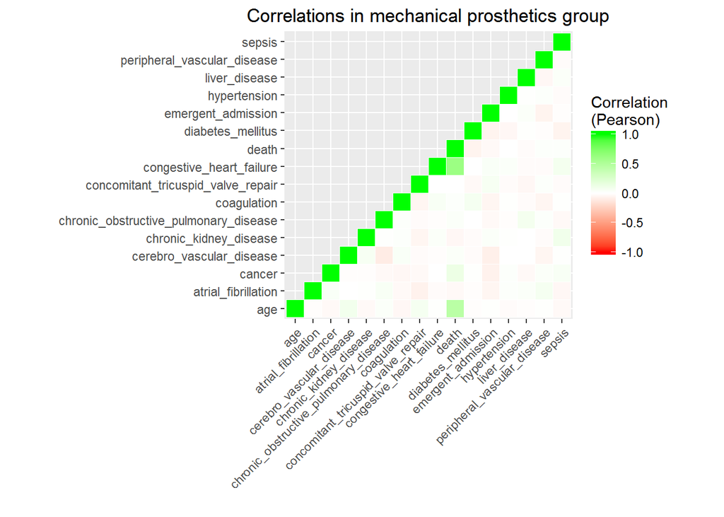

```r
thecor<-melt(thecor)
thecor$Var1<-as.character(thecor$Var1)
thecor$Var2<-as.character(thecor$Var2)
#Now we will use the "long" format using the melt function from the reshape2 package and I'll drop the records with NA values.
thecor<-na.omit(thecor)

ggplot(thecor, aes(Var2, Var1))+
 geom_tile(data=thecor, aes(fill=value), color="white")+
 scale_fill_gradient2(low="red", high="green", mid="white",
  midpoint=0, limit=c(-1,1),name="Correlation\n(Pearson)")+
 theme(axis.text.x = element_text(angle=45, vjust=1, hjust=1))+
 coord_equal() +
  labs(title="Correlations in mechanical prosthetics group" , x = "", y = "")
```

Positive Correlations Apart from the correlations we generated while simlating the death variable, we see some more interesting positive correlations in the data. These correlations are not that stroong though. These are: Sepsis and chronic kidney disease, diabetes mellitus and coagulation. Age and death ofcourse show high positive correlatin as they are intentionally coded that way. Similary death and congestive heart failure show strong positive correlation.